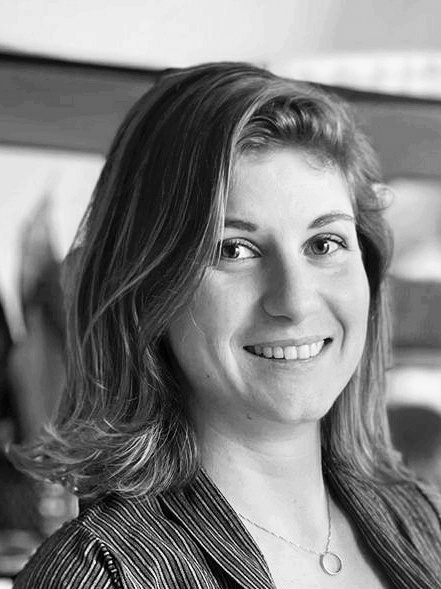

# Hélène Cecilia

## Bio

I am a mathematical modeler, specialized in the ecology and epidemiology of vector-borne, zoonotic diseases.

I have studied the impact of abiotic factors on the population dynamics of insect vectors, and how the fragmentation of the habitat due to human activites can create source-sink dynamics that can jeopardize control efforts. I have mapped the epidemic potential of complex multi-host, multi-vector systems in a seasonal environment. I have also worked at the within-host scale, comparing viral dynamics and host-to-vector transmission patterns of different vertberate host species and viral strains.

My research interests are now focused on assessing the impact of individual heterogeneities on transmission dynamics at the population scale, and, methodologically, on the best approach to couple these different scales. I mostly use mechanistic modeling, but I can also use statistical models, particularly to exploit experimental data.

Please reach out if you think a collaboration could be of interest, or if you’re a prospective master/PhD student, or postdoc. I’m also very keen on scientific outreach activities.

## Education & Experience

**INRAE Animal Health Department (Dynamo team, BIOEPAR lab, Oniris)** | Permanent Researcher | October 2024 - Present

*Multi-scale modeling of vector-borne diseases*

**New Mexico State University (Hanley Lab)** | January 2022 - September 2024

*Transmission-clearance trade-offs in native and novel hosts of Zika and dengue viruses*

**INRAE Animal Health Department (Dynamo team, BIOEPAR lab, Oniris)** | Ph.D. in Epidemiological Modeling | October 2018 - 2021

*Modeling Rift Valley fever virus dynamics : insight from micro- to macro-scale studies*

Collaborated with Wageningen University and Research (Prof. Quirine ten Bosch)

**INRAE Animal Health Department (Dynamo team, BIOEPAR lab, Oniris)** | Research Assistant | January 2016 - October 2017

*Modeling tsetse fly population dynamics to inform control strategies*

**National Institutes of Science and Technology** | Lyon, France

M.S. in Bioinformatics and Mathematical Modeling | 2012 - 2015

B.S. in General Engineering | 2010 - 2012